# Handling Time Series with Pandas

A **time series** is made up of data points that are **indexed in time order**. Since this is just a special type of data frame, `pandas` has very good support for working with time series data.

```python
%matplotlib inline
```

```python
import pandas
import seaborn
import matplotlib.pyplot as plt
```

```python
seaborn.set_style("ticks")
plt.rcParams["axes.grid"] = True
plt.rcParams["figure.figsize"] = (15, 5)
```

## Example: The Bitcoin Price Over Time

Due to varying interest and hype, the price of Bitcoin (BTC) is extremely volatile. Clearly, understanding trends or even predicting future values of this time series could pay off - let's see what we can find out.

```python
data_path = "../.assets/data/bitcoin/BTC_USD Bitfinex Historical Data.csv"
```

```python
data = pandas.read_csv(data_path)
```

```python
data.head()
```

|  | Date | Price | Open | High | Low | Vol. | Change % |
| --- | --- | --- | --- | --- | --- | --- | --- |
| 0 | Sep 19, 2018 | 6,288.5 | 6,330.8 | 6,364.9 | 6,257.1 | 14.60K | -0.86% |
| 1 | Sep 18, 2018 | 6,342.8 | 6,243.0 | 6,384.0 | 6,229.2 | 15.93K | 1.42% |
| 2 | Sep 17, 2018 | 6,254.2 | 6,506.1 | 6,532.8 | 6,205.1 | 23.54K | -3.76% |
| 3 | Sep 16, 2018 | 6,498.5 | 6,512.8 | 6,517.8 | 6,384.5 | 8.73K | -0.23% |
| 4 | Sep 15, 2018 | 6,513.6 | 6,480.1 | 6,568.9 | 6,473.6 | 8.35K | 0.44% |

```python
data.dtypes
```

```
Date        object
Price       object
Open        object
High        object
Low         object
Vol.        object
Change %    object
dtype: object
```

By default, pandas has read all fields as strings (`numpy` datatype `object`). There is however a special efficient datatype to represent timestamps: `datetime64`. Our first step in every time series analysis should be to identify the time column, convert it to `datetime64` and make it the **index** of the dataframe. In `pandas`, a time series is simply a `pandas.DataFrame` or `pandas.Series` with a `pandas.DateTimeIndex`:

```python
data = pandas.read_csv(data_path, parse_dates=["Date"])
```

```python
data.dtypes
```

```
Date        datetime64[ns]
Price               object
Open                object
High                object
Low                 object
Vol.                object
Change %            object
dtype: object
```

```python
data.head()
```

|  | Date | Price | Open | High | Low | Vol. | Change % |
| --- | --- | --- | --- | --- | --- | --- | --- |
| 0 | 2018-09-19 | 6,288.5 | 6,330.8 | 6,364.9 | 6,257.1 | 14.60K | -0.86% |
| 1 | 2018-09-18 | 6,342.8 | 6,243.0 | 6,384.0 | 6,229.2 | 15.93K | 1.42% |
| 2 | 2018-09-17 | 6,254.2 | 6,506.1 | 6,532.8 | 6,205.1 | 23.54K | -3.76% |
| 3 | 2018-09-16 | 6,498.5 | 6,512.8 | 6,517.8 | 6,384.5 | 8.73K | -0.23% |
| 4 | 2018-09-15 | 6,513.6 | 6,480.1 | 6,568.9 | 6,473.6 | 8.35K | 0.44% |

```python
data = data.set_index("Date")
```

```python
data.index
```

```
DatetimeIndex(['2018-09-19', '2018-09-18', '2018-09-17', '2018-09-16',
               '2018-09-15', '2018-09-14', '2018-09-13', '2018-09-12',
               '2018-09-11', '2018-09-10',
               ...
               '2014-08-28', '2014-08-27', '2014-08-26', '2014-08-25',
               '2014-08-24', '2014-08-23', '2014-08-22', '2014-08-21',
               '2014-08-20', '2014-08-19'],
              dtype='datetime64[ns]', name='Date', length=1478, freq=None)
```

```python
data.head()
```

| Date | Price | Open | High | Low | Vol. | Change % |
| --- | --- | --- | --- | --- | --- | --- |
| 2018-09-19 | 6,288.5 | 6,330.8 | 6,364.9 | 6,257.1 | 14.60K | -0.86% |
| 2018-09-18 | 6,342.8 | 6,243.0 | 6,384.0 | 6,229.2 | 15.93K | 1.42% |
| 2018-09-17 | 6,254.2 | 6,506.1 | 6,532.8 | 6,205.1 | 23.54K | -3.76% |
| 2018-09-16 | 6,498.5 | 6,512.8 | 6,517.8 | 6,384.5 | 8.73K | -0.23% |
| 2018-09-15 | 6,513.6 | 6,480.1 | 6,568.9 | 6,473.6 | 8.35K | 0.44% |

Let's also get the index sorted:

```python
data.index.is_monotonic
```

```
False
```

```python
data = data.sort_index()
```

```python
data.index.is_monotonic
```

```
True
```

The `pandas.DateTimeIndex` can be used to access data points by time. The `pandas.DataFrame.loc` indexer accepts strings representing time in many formats. For example, getting the data points from January 2018 looks like this...

```python
data.loc["2018-01"]
```

| Date | Price | Open | High | Low | Vol. | Change % |
| --- | --- | --- | --- | --- | --- | --- |
| 2018-01-01 | 13,354.0 | 13,794.0 | 13,893.0 | 12,787.0 | 29.54K | -3.23% |
| 2018-01-02 | 14,709.8 | 13,448.0 | 15,300.0 | 12,810.0 | 56.18K | 10.15% |
| 2018-01-03 | 15,155.0 | 14,713.0 | 15,428.0 | 14,522.0 | 38.35K | 3.03% |
| 2018-01-04 | 15,160.0 | 15,150.0 | 15,390.0 | 14,064.0 | 46.47K | 0.03% |
| 2018-01-05 | 16,917.0 | 15,159.0 | 17,101.0 | 14,769.0 | 54.63K | 11.59% |
| 2018-01-06 | 17,161.0 | 16,911.0 | 17,252.0 | 16,251.0 | 29.61K | 1.44% |
| 2018-01-07 | 16,196.0 | 17,163.0 | 17,176.0 | 15,726.0 | 30.84K | -5.62% |
| 2018-01-08 | 14,930.0 | 16,216.0 | 16,279.0 | 13,760.0 | 64.95K | -7.82% |
| 2018-01-09 | 14,423.0 | 14,902.0 | 15,355.0 | 14,122.0 | 43.44K | -3.40% |
| 2018-01-10 | 14,896.0 | 14,426.0 | 14,896.0 | 13,338.0 | 57.33K | 3.28% |
| 2018-01-11 | 13,266.0 | 14,895.0 | 14,949.8 | 12,639.0 | 71.70K | -10.94% |
| 2018-01-12 | 13,783.0 | 13,248.0 | 14,095.0 | 12,778.0 | 37.42K | 3.90% |
| 2018-01-13 | 14,191.0 | 13,794.0 | 14,580.0 | 13,760.0 | 29.01K | 2.96% |
| 2018-01-14 | 13,558.0 | 14,190.0 | 14,391.0 | 12,874.3 | 35.60K | -4.46% |
| 2018-01-15 | 13,575.0 | 13,558.0 | 14,350.0 | 13,307.0 | 33.46K | 0.13% |
| 2018-01-16 | 11,072.0 | 13,594.0 | 13,604.0 | 9,949.4 | 131.86K | -18.44% |
| 2018-01-17 | 11,082.0 | 11,059.0 | 11,490.0 | 9,231.1 | 132.23K | 0.09% |
| 2018-01-18 | 11,045.0 | 11,101.0 | 11,881.0 | 10,515.0 | 85.24K | -0.33% |
| 2018-01-19 | 11,476.0 | 11,036.0 | 11,879.0 | 10,649.0 | 48.55K | 3.90% |
| 2018-01-20 | 12,728.0 | 11,462.0 | 13,002.0 | 11,425.0 | 46.30K | 10.91% |
| 2018-01-21 | 11,514.0 | 12,732.0 | 12,732.0 | 11,020.0 | 53.62K | -9.54% |
| 2018-01-22 | 10,771.0 | 11,519.0 | 11,886.0 | 10,009.0 | 66.35K | -6.45% |
| 2018-01-23 | 10,819.0 | 10,770.0 | 11,383.0 | 9,901.1 | 63.85K | 0.45% |
| 2018-01-24 | 11,414.0 | 10,811.0 | 11,529.0 | 10,454.0 | 43.82K | 5.50% |
| 2018-01-25 | 11,146.0 | 11,402.0 | 11,723.0 | 10,857.0 | 34.44K | -2.35% |
| 2018-01-26 | 11,070.0 | 11,144.0 | 11,647.0 | 10,298.0 | 56.75K | -0.68% |
| 2018-01-27 | 11,461.0 | 11,068.0 | 11,683.0 | 10,822.0 | 34.40K | 3.53% |
| 2018-01-28 | 11,839.0 | 11,455.1 | 12,181.0 | 11,398.0 | 29.62K | 3.30% |
| 2018-01-29 | 11,212.0 | 11,836.0 | 11,957.0 | 11,074.0 | 25.65K | -5.30% |
| 2018-01-30 | 10,175.0 | 11,215.0 | 11,250.0 | 9,864.9 | 61.28K | -9.25% |
| 2018-01-31 | 10,284.0 | 10,170.0 | 10,411.0 | 9,761.0 | 43.23K | 1.07% |

... or like this:

```python
data.loc["January 2018"]
```

| Date | Price | Open | High | Low | Vol. | Change % |
| --- | --- | --- | --- | --- | --- | --- |
| 2018-01-01 | 13,354.0 | 13,794.0 | 13,893.0 | 12,787.0 | 29.54K | -3.23% |
| 2018-01-02 | 14,709.8 | 13,448.0 | 15,300.0 | 12,810.0 | 56.18K | 10.15% |
| 2018-01-03 | 15,155.0 | 14,713.0 | 15,428.0 | 14,522.0 | 38.35K | 3.03% |
| 2018-01-04 | 15,160.0 | 15,150.0 | 15,390.0 | 14,064.0 | 46.47K | 0.03% |
| 2018-01-05 | 16,917.0 | 15,159.0 | 17,101.0 | 14,769.0 | 54.63K | 11.59% |
| 2018-01-06 | 17,161.0 | 16,911.0 | 17,252.0 | 16,251.0 | 29.61K | 1.44% |
| 2018-01-07 | 16,196.0 | 17,163.0 | 17,176.0 | 15,726.0 | 30.84K | -5.62% |
| 2018-01-08 | 14,930.0 | 16,216.0 | 16,279.0 | 13,760.0 | 64.95K | -7.82% |
| 2018-01-09 | 14,423.0 | 14,902.0 | 15,355.0 | 14,122.0 | 43.44K | -3.40% |
| 2018-01-10 | 14,896.0 | 14,426.0 | 14,896.0 | 13,338.0 | 57.33K | 3.28% |
| 2018-01-11 | 13,266.0 | 14,895.0 | 14,949.8 | 12,639.0 | 71.70K | -10.94% |
| 2018-01-12 | 13,783.0 | 13,248.0 | 14,095.0 | 12,778.0 | 37.42K | 3.90% |
| 2018-01-13 | 14,191.0 | 13,794.0 | 14,580.0 | 13,760.0 | 29.01K | 2.96% |
| 2018-01-14 | 13,558.0 | 14,190.0 | 14,391.0 | 12,874.3 | 35.60K | -4.46% |
| 2018-01-15 | 13,575.0 | 13,558.0 | 14,350.0 | 13,307.0 | 33.46K | 0.13% |
| 2018-01-16 | 11,072.0 | 13,594.0 | 13,604.0 | 9,949.4 | 131.86K | -18.44% |
| 2018-01-17 | 11,082.0 | 11,059.0 | 11,490.0 | 9,231.1 | 132.23K | 0.09% |
| 2018-01-18 | 11,045.0 | 11,101.0 | 11,881.0 | 10,515.0 | 85.24K | -0.33% |
| 2018-01-19 | 11,476.0 | 11,036.0 | 11,879.0 | 10,649.0 | 48.55K | 3.90% |
| 2018-01-20 | 12,728.0 | 11,462.0 | 13,002.0 | 11,425.0 | 46.30K | 10.91% |
| 2018-01-21 | 11,514.0 | 12,732.0 | 12,732.0 | 11,020.0 | 53.62K | -9.54% |
| 2018-01-22 | 10,771.0 | 11,519.0 | 11,886.0 | 10,009.0 | 66.35K | -6.45% |
| 2018-01-23 | 10,819.0 | 10,770.0 | 11,383.0 | 9,901.1 | 63.85K | 0.45% |
| 2018-01-24 | 11,414.0 | 10,811.0 | 11,529.0 | 10,454.0 | 43.82K | 5.50% |
| 2018-01-25 | 11,146.0 | 11,402.0 | 11,723.0 | 10,857.0 | 34.44K | -2.35% |
| 2018-01-26 | 11,070.0 | 11,144.0 | 11,647.0 | 10,298.0 | 56.75K | -0.68% |
| 2018-01-27 | 11,461.0 | 11,068.0 | 11,683.0 | 10,822.0 | 34.40K | 3.53% |
| 2018-01-28 | 11,839.0 | 11,455.1 | 12,181.0 | 11,398.0 | 29.62K | 3.30% |
| 2018-01-29 | 11,212.0 | 11,836.0 | 11,957.0 | 11,074.0 | 25.65K | -5.30% |
| 2018-01-30 | 10,175.0 | 11,215.0 | 11,250.0 | 9,864.9 | 61.28K | -9.25% |
| 2018-01-31 | 10,284.0 | 10,170.0 | 10,411.0 | 9,761.0 | 43.23K | 1.07% |

Let's also fix the data types. Clearly, the price should be a floating point number:

```python
data["Price"] = data["Price"].str.replace(",", "").astype("float")
```

```python
data.head()
```

| Date | Price | Open | High | Low | Vol. | Change % |
| --- | --- | --- | --- | --- | --- | --- |
| 2014-08-19 | 490.3 | 470.0 | 498.0 | 470.0 | 1.43K | 2.53% |
| 2014-08-20 | 517.0 | 492.1 | 525.0 | 471.7 | 1.15K | 5.44% |
| 2014-08-21 | 515.9 | 515.6 | 529.0 | 510.0 | 1.52K | -0.21% |
| 2014-08-22 | 515.6 | 518.4 | 521.5 | 502.0 | 0.79K | -0.06% |
| 2014-08-23 | 500.1 | 510.5 | 511.6 | 499.0 | 0.91K | -2.99% |

We can plot the values of a time series using the known `pandas` methods:

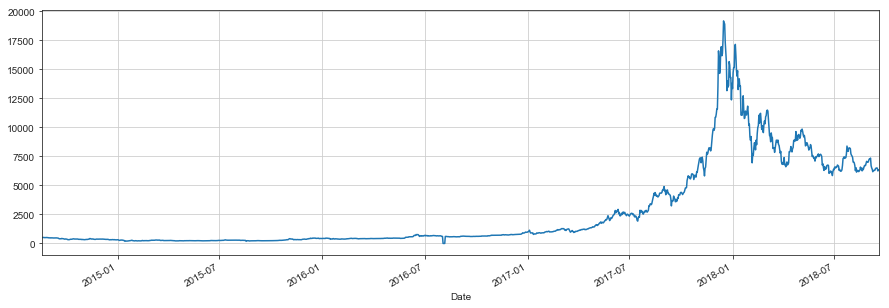

```python
data["Price"].plot(kind="line")
```

Often, one would like to look at a smoother version of the time series to identify trends rather than random noise. Smoothing can be done in various ways, for example by **resampling** it to a new frequency: Here we convert daily data points to weekly data points by taking the median of the values of each week. Notice how this is done by chaining the `resample` and `median` method calls, and how this works pretty much like the `groupby` method we have already seen.

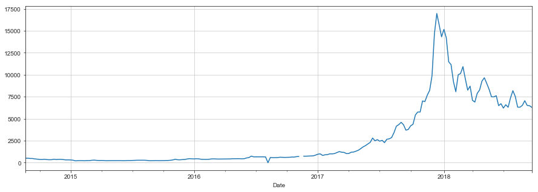

```python
data["Price"].resample('1w').median().plot(kind="line")
```

Another way to obtain a smoother time series is applying a **[moving average](https://en.wikipedia.org/wiki/Moving_average)** operation:

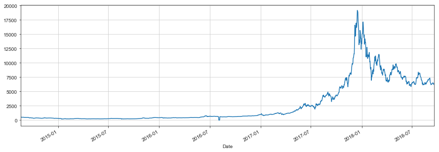

```python
data["Price"].plot(kind="line")
```

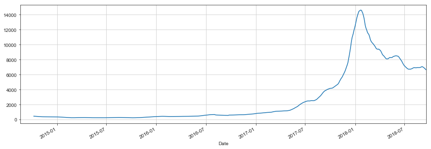

```python
data["Price"].rolling(50).mean().plot(kind="line")
```

What we did here is move a window of size 50 values over the time series and build a new time series from the mean of the 50 values in the window.

```python
data["Price"].rolling(50).mean().head(51)
```

```
Date
2014-08-19        NaN
2014-08-20        NaN
2014-08-21        NaN
2014-08-22        NaN
2014-08-23        NaN
2014-08-24        NaN
2014-08-25        NaN
2014-08-26        NaN
2014-08-27        NaN
2014-08-28        NaN
2014-08-29        NaN
2014-08-30        NaN
2014-08-31        NaN
2014-09-01        NaN
2014-09-02        NaN
2014-09-03        NaN
2014-09-04        NaN
2014-09-05        NaN
2014-09-06        NaN
2014-09-07        NaN
2014-09-08        NaN
2014-09-09        NaN
2014-09-10        NaN
2014-09-11        NaN
2014-09-12        NaN
2014-09-13        NaN
2014-09-14        NaN
2014-09-15        NaN
2014-09-16        NaN
2014-09-17        NaN
2014-09-18        NaN
2014-09-19        NaN
2014-09-20        NaN
2014-09-21        NaN
2014-09-22        NaN
2014-09-23        NaN
2014-09-24        NaN
2014-09-25        NaN
2014-09-26        NaN
2014-09-27        NaN
2014-09-28        NaN
2014-09-29        NaN
2014-09-30        NaN
2014-10-01        NaN
2014-10-02        NaN
2014-10-03        NaN
2014-10-04        NaN
2014-10-05        NaN
2014-10-06        NaN
2014-10-07    445.742
2014-10-08    442.936
Name: Price, dtype: float64
```

*This notebook is licensed under a [Creative Commons Attribution 4.0 International License (CC BY 4.0)](https://creativecommons.org/licenses/by/4.0/). Copyright © 2019 [Point 8 GmbH](https://point-8.de)*